# Geolift

An end-to-end solution to Measure Lift at a Geo Level

Author

Department of Marketing Science at StitcherAds

Abstract

Client GeoLift using Units Sold and Revenue across 46 state markets and 68 weeks of Pre-Test data. Initial data contained 51 US markets, however, only markets within the top 80% of conversions were input into the lift model.

# 1. Introduction

**What is Lift?**

Lift is a scientific measurement technique which allows users to accurately understand and compare the value of their strategies. Lift, which is grounded on experimental design, is typically used to measure the true or *causal* effect that an ad campaign had on business metrics such as Sales, App Installs, or Leads. By estimating the *incremental* effect that these strategies provide, analysts are able to understand, analyze, and optimize their cross-channel strategies through data and science.

**What is Geo-Experimentation?**

There are many ways to measure Lift and Geo Experimentation is one that has been rapidly gaining popularity. In general, Geo Experimentation refers to any test where the treatment is administered at the geo-level. In practice, this often means that ad campaigns are geo-targeted in such a way that the test regions are eligible to see ads while the control ones aren’t. Geo Experimental methods use this information to calculate the true value that this strategy had on your audience. Moreover, since they rely on aggregated data they’re privacy-safe, can work across channels, and are very robust against signal-loss.

**Why GeoLift?**

GeoLift is a solution to measure Lift at a geographical level. By leveraging the latest advances in Synthetic Control Methods, GeoLift empowers you to start making decisions grounded in incrementality and measure the true value of your marketing campaigns. This tool offers an end-to-end solution to geo-experimentation which spans data ingestion, power analyses, market selection, and inference.

# 2. Historical Data

For this end-to-end case-study implementation of GeoLift, we will use client-provided **data** from **46 U.S. Markets** across **68 weeks** to:

- design a test
- select test markets
- run power calculations
- and calculate the Lift caused by the campaign.

Every GeoLift experiment should contain at least three variables that reflect:

- location (*where*)
- date (*when*)
- Y (*how much* of the KPI was measured).

If you have more data available, you can include `covariates` through the **`X`** parameter of all Lift functions to improve results.

| date | location | revenue | Y |
| --- | --- | --- | --- |
| 2022-07-03 | Utah | 12099.9 | 65 |
| 2021-06-27 | Wisconsin | 557.0 | 4 |
| 2022-02-20 | New Mexico | 755.0 | 5 |
| 2021-12-19 | North Carolina | 2133.0 | 14 |
| 2022-03-13 | Arkansas | 871.0 | 7 |

# 3. Pre-Test Data Plot

| Summary of Pre-Test Data |
| --- |
| Initial Number of Locations: 46 |
| Weekly Time Stamps: 68 |
| Final Number of Locations (Complete): 46 |

| location | time | Y | revenue |
| --- | --- | --- | --- |
| alabama | 1 | 4 | 567 |
| alabama | 2 | 4 | 567 |
| alabama | 3 | 2 | 378 |
| alabama | 4 | 2 | 328 |
| alabama | 5 | 2 | 378 |

Input data post-transformation

Addressing Raw vs. Complete Locations:

Before reading the data into this format, always make sure that there are no missing variables, NAs, or locations with missing time-stamps as those will be dropped by the input function, resulting in fewer ‘Complete’ markets than what was contained in the original dataset.

Plotting the panel data will allow us to observe:

- trend
- contribution per location
- any data anomalies

We can see a similar pattern that’s shared across all 46 markets. These structural similarities between regions are the key to a successful test.

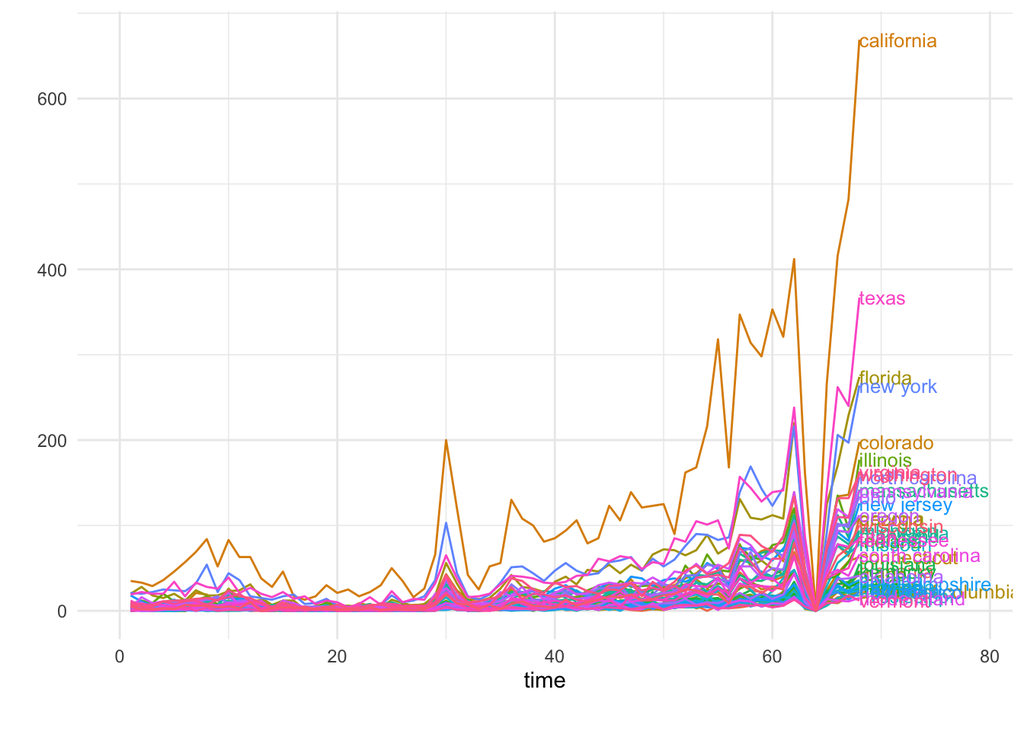

Pre-Test market conversions across 68 weeks

# 4. Test Market Selection

Running the power-analysis will provide:

- The optimal number of test locations.
- Best test duration.
- Ideal test and control markets.
- Estimate of the budget needed to run the test.
- Minimum Detectable Effect to obtain significant results.

Definitions of Input Parameters can be found here. Power Analysis Definitions

The table below displays the top 10 Test Market Groups based on the initial algorithm build. **There are 804 total** available to inspect. For report purposes, we’ll only plot the first few results. These plots show what a *simulated lift* would look like with the latest possible test period as well as the test’s power curve across all simulations for the specified test market group.

Ranking variables info can be found here. Market Selections Output

| ID | location | duration | EffectSize | Power | AvgScaledL2Imbalance | Investment | AvgATT | Average_MDE | ProportionTotal_Y | abs_lift_in_zero | Holdout | rank | correlation |
| --- | --- | --- | --- | --- | --- | --- | --- | --- | --- | --- | --- | --- | --- |
| 1 | florida, kansas, tennessee | 6 | 0.250 | 1 | 0.4064457 | 26471.250 | 22.596789 | 0.2496105 | 0.0846284 | 0.000 | 0.9153716 | 1 | 0.9894947 |
| 2 | florida, mississippi, pennsylvania | 3 | 0.025 | 1 | 0.3183124 | 1421.875 | 2.344329 | 0.0240917 | 0.0980437 | 0.001 | 0.9019563 | 1 | 0.9911106 |
| 3 | maryland, oregon, washington | 3 | 0.250 | 1 | 0.3840497 | 11456.250 | 19.574661 | 0.2498616 | 0.0803929 | 0.000 | 0.9196071 | 1 | 0.9910270 |
| 4 | connecticut, florida, indiana, kansas, kentucky, tennessee | 6 | 0.250 | 1 | 0.4792060 | 38041.250 | 16.227179 | 0.2494281 | 0.1217760 | 0.001 | 0.8782240 | 4 | 0.9887116 |
| 5 | massachusetts, michigan, new jersey, new york, north carolina, pennsylvania, texas, washington | 3 | 0.250 | 1 | 0.1402194 | 43907.500 | 28.055226 | 0.2489948 | 0.3301251 | 0.001 | 0.6698749 | 4 | 0.9952520 |
| 6 | arizona, georgia, illinois, massachusetts, michigan, minnesota, pennsylvania, tennessee, texas, washington | 4 | 0.250 | 1 | 0.1844744 | 64122.500 | 24.841007 | 0.2522660 | 0.3220495 | 0.002 | 0.6779505 | 6 | 0.9936428 |
| 7 | arizona, georgia, illinois, massachusetts, minnesota, new jersey, new mexico, pennsylvania, tennessee, texas | 2 | 0.250 | 1 | 0.2616899 | 26162.500 | 20.222419 | 0.2515145 | 0.2967352 | 0.002 | 0.7032648 | 6 | 0.9922728 |
| 8 | arizona, georgia, illinois, massachusetts, minnesota, new jersey, new mexico, pennsylvania, tennessee, texas | 4 | 0.250 | 1 | 0.2224972 | 58548.750 | 22.374235 | 0.2479977 | 0.2967352 | 0.002 | 0.7032648 | 6 | 0.9922728 |
| 9 | arkansas, michigan, minnesota, new hampshire, new york, ohio, south carolina, texas | 3 | 0.250 | 1 | 0.2321675 | 32776.250 | 20.884402 | 0.2481285 | 0.2368113 | 0.002 | 0.7631887 | 6 | 0.9952518 |
| 10 | colorado, florida, georgia, illinois, kentucky, maryland, massachusetts, michigan, minnesota, nevada, new hampshire, new york, ohio, oklahoma, oregon, pennsylvania, tennessee, texas, washington, wisco… | 2 | 0.250 | 1 | 0.2055022 | 51025.000 | 19.734553 | 0.2517469 | 0.5816207 | 0.002 | 0.4183793 | 6 | 0.9895329 |

# 5. Assess Market Selections

We can take a high-level look at multiple individual plots to determine which to proceed with for further analysis.

Each plot indicates how a simulated lift would appear with the latest possible test period applied to it, as well as the test’s power curve across all of its simulations. We’ll take a look at a sample of 2 Test Markets Groups.

**Market ID# 2**

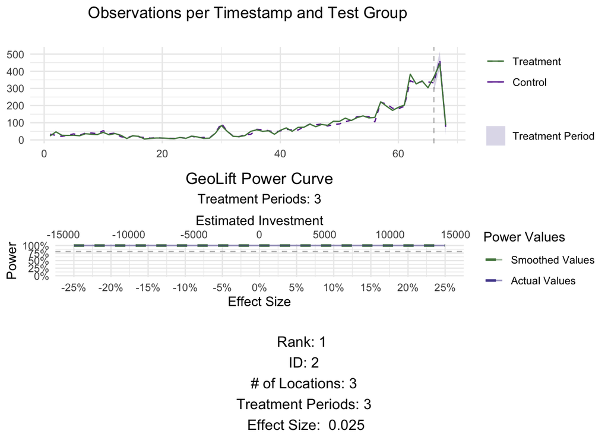

> **Test Markets**: *florida, mississippi, pennsylvania*

**Market ID# 3**

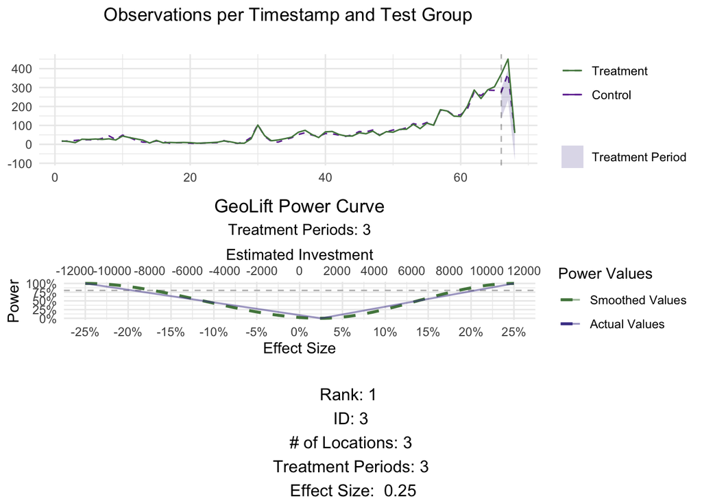

> **Test Markets**: *maryland, oregon, washington*

# 6. Narrowed Test Market Selection

Once all initial plots have been inspected, a narrowed list is produced.

| ID | location | duration | EffectSize | Power | AvgScaledL2Imbalance | Investment | AvgATT | Average_MDE | ProportionTotal_Y | abs_lift_in_zero | Holdout | rank | correlation |
| --- | --- | --- | --- | --- | --- | --- | --- | --- | --- | --- | --- | --- | --- |
| 2 | florida, mississippi, pennsylvania | 3 | 0.025 | 1 | 0.3183124 | 1421.875 | 2.344329 | 0.0240917 | 0.0980437 | 0.001 | 0.9019563 | 1 | 0.9911106 |
| 15 | florida, mississippi, new hampshire, ohio, oklahoma, pennsylvania | 3 | 0.025 | 1 | 0.5612615 | 2083.250 | 1.408616 | 0.0196750 | 0.1411408 | 0.005 | 0.8588592 | 14 | 0.9916811 |
| 27 | connecticut, florida, new york, ohio, oklahoma, tennessee, vermont, washington | 6 | 0.250 | 1 | 0.2666061 | 71613.750 | 23.465190 | 0.2570107 | 0.2364487 | 0.007 | 0.7635513 | 25 | 0.9961952 |
| 28 | florida, georgia, illinois, maryland, massachusetts, michigan, new hampshire, new jersey, new york, north carolina, ohio, pennsylvania, rhode island, virginia, washington | 3 | 0.250 | 1 | 0.1597716 | 64106.250 | 22.410045 | 0.2570747 | 0.4662557 | 0.007 | 0.5337443 | 25 | 0.9950099 |
| 39 | colorado, florida, georgia, michigan, oklahoma, washington | 6 | 0.250 | 1 | 0.2475033 | 59735.000 | 24.613383 | 0.2389057 | 0.1901050 | 0.011 | 0.8098950 | 38 | 0.9941621 |
| 55 | connecticut, florida, kentucky, maryland, new york, ohio, oklahoma, tennessee, vermont, washington | 6 | 0.025 | 1 | 0.3123229 | 8037.250 | 3.333548 | 0.0410735 | 0.2646143 | 0.016 | 0.7353857 | 54 | 0.9962540 |

# 7. Deeper Dive into the Narrowed Test Markets List

After deciding on a narrowed of Test Market Groups to proceed with, we will ensure that the power is consistent throughout time for these locations by running the the power analysis method again and expanding our `lookback_window` to a greater number of weeks for each treatment combination and plot the results.

**Market ID# 2**

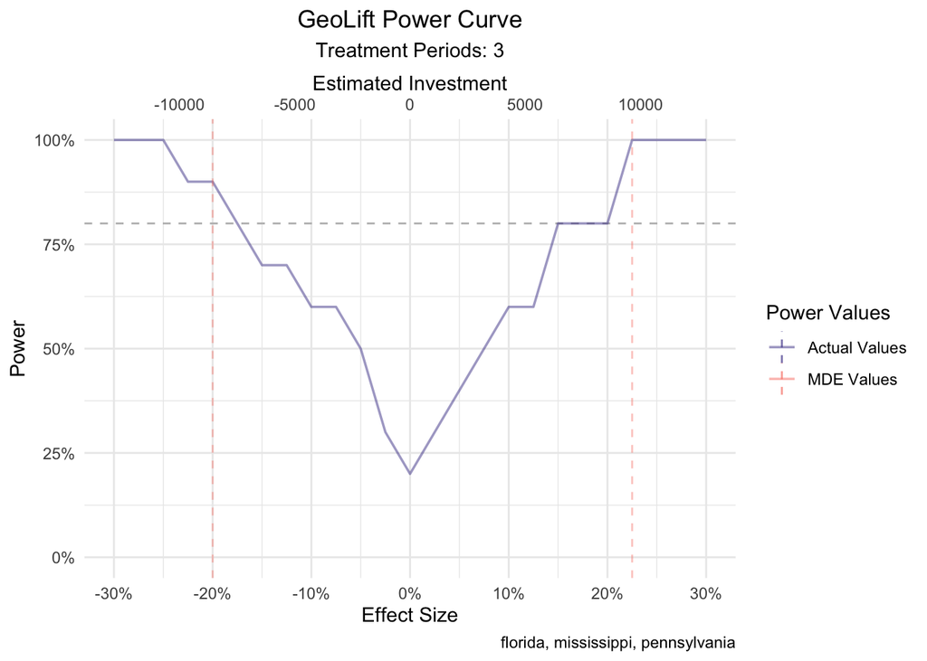

**Market ID# 15**

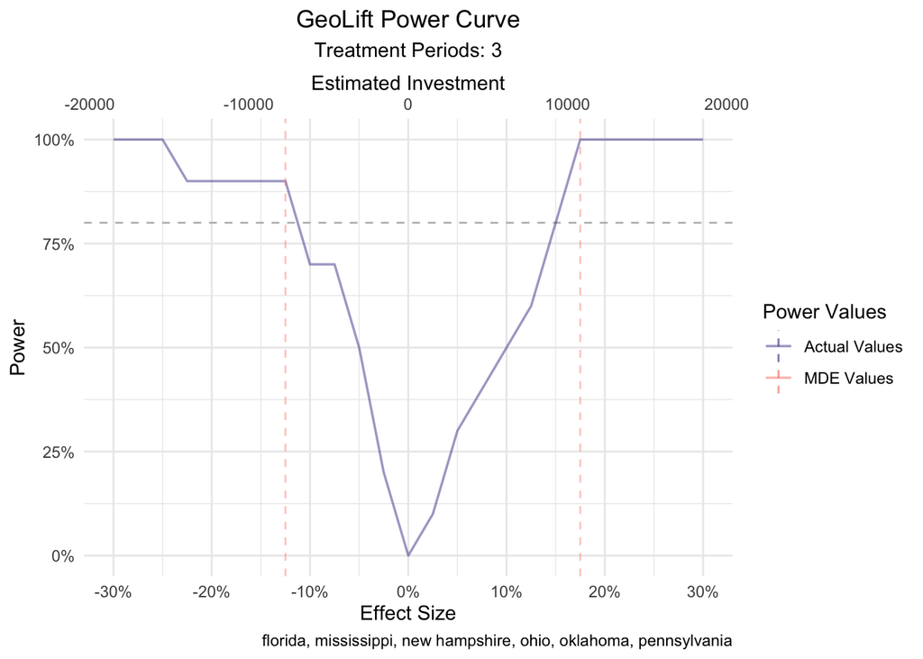

**Market ID# 27**

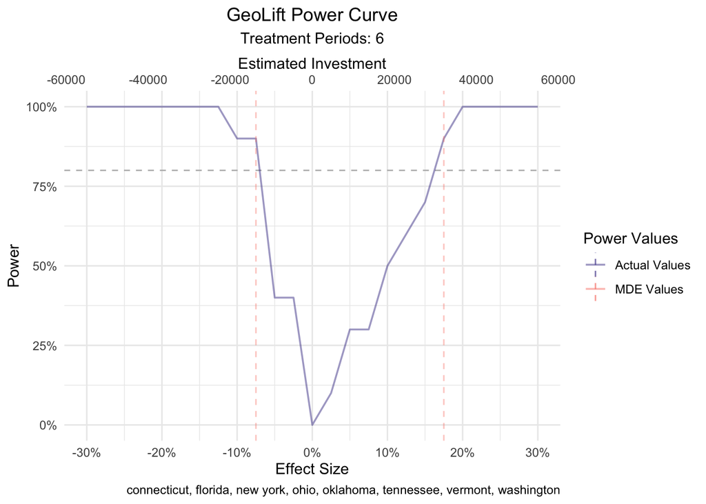

**Market ID# 28**

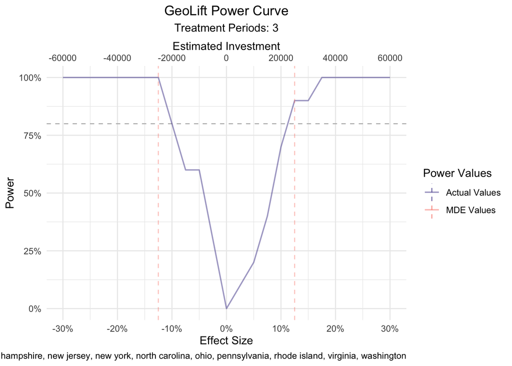

**Market ID# 39**

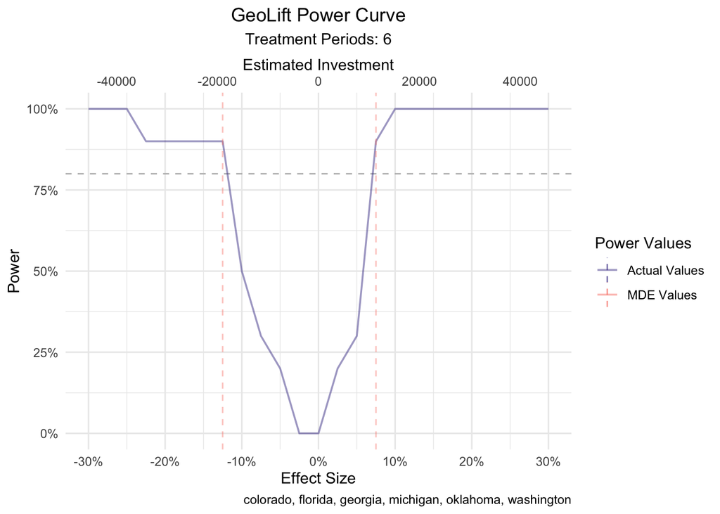

At this point, we need to pause and align our suggestion for test market selection with client needs. Once expectations are aligned, we can move forward having established the following:

- The optimal number of test locations.
- Best test duration.
- Ideal test/control markets.
- A good estimate of the budget needed to run the test.
- The Minimum Detectable Effect to obtain significant results.

# 8. Next Steps

Based on the results of the Power Calculations, we’ll select model #28 and a test will be set-up with corresponding:

- budget = $64K
- duration = 3 Weeks
- test markets (15) = Florida, Georgia, Illinois, Maryland, Massachusetts, Michigan, New Hampshire, New Jersey, New York, North Carolina, Ohio, Pennsylvania, Rhode Island, Virginia, Washington
- MDE = 25%

Following completion from this marketing campaign, we’ll receive sales data that reflects these results. This new data-set will contains the same format and information as the pre-test one but crucially include results from the duration of the campaign. Depending on the vertical and product, adding a post-campaign cooldown period might be useful. :::

# 9. GeoLift Results

| Summary of Test Data |
| --- |
| Number of Locations: 46 |
| Total Time Periods: 73 |
| Pre-Test Time Periods: 68 |
| Final Number of Locations (Complete): 46 |

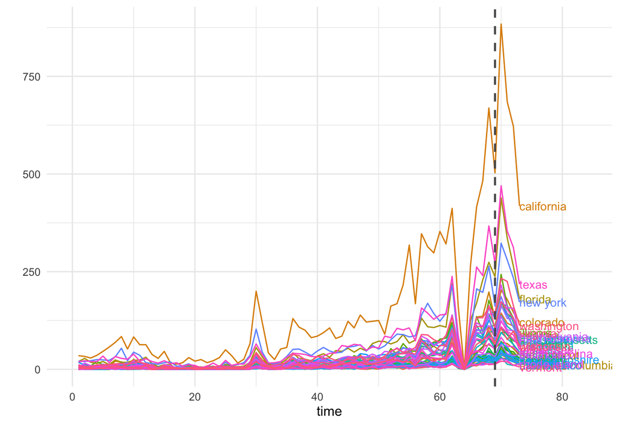

Timestamp indicates start of testing period

## Model Run: Market 28

**Simulated Lift**

| Simulating 25% lift using Pre-Test data |
| --- |

| GeoLift Output |
| --- |
| Test results for 3 treatment periods, from time-stamp 66 to 68 for test markets: |
| 1 FLORIDA |
| 2 GEORGIA |
| 3 ILLINOIS |
| 4 MARYLAND |
| 5 MASSACHUSETTS |
| 6 MICHIGAN |
| 7 NEW HAMPSHIRE |
| 8 NEW JERSEY |
| 9 NEW YORK |
| 10 NORTH CAROLINA |
| 11 OHIO |
| 12 PENNSYLVANIA |
| 13 RHODE ISLAND |
| 14 VIRGINIA |
| 15 WASHINGTON |
| ################################## |
| ##### Test Statistics ##### |
| ################################## |
| Percent Lift: 25.7% |
| Incremental Y: 1008 |
| Average Estimated Treatment Effect (ATT): 22.394 |
| The results are significant at a 95% level. (ONE-SIDED POSITIVE LIFT TEST) |
| There is a 0% chance of observing an effect this large or larger assuming treatment effect is zero. |

**Synthetic Controls**

| Total # of Control Markets: 31 |
| --- |

| Total # of Markets Shown: 20 |
| --- |

| oklahoma | 0.2181372 |
| --- | --- |
| texas | 0.1617271 |
| oregon | 0.1508590 |
| minnesota | 0.1369008 |
| maine | 0.1149840 |
| california | 0.0532302 |
| alabama | 0.0514626 |
| south carolina | 0.0408154 |
| louisiana | 0.0362584 |
| district of columbia | 0.0320645 |
| arizona | 0.0035608 |
| utah | 0.0000000 |
| kentucky | 0.0000000 |
| tennessee | 0.0000000 |
| alaska | 0.0000000 |
| new mexico | 0.0000000 |
| idaho | 0.0000000 |
| kansas | 0.0000000 |
| nevada | 0.0000000 |
| indiana | 0.0000000 |

Partial list of holdout markets (and associated actual weights) comprising the synthetic control

**Calculated Lift**

| GeoLift Results Summary |
| --- |
| - Test Statistics |
| Average ATT: 2.217 |
| Percent Lift: 1.5% |
| Incremental Y: 100 |
| P-value: 0.06 |
| - Balance Statistics |
| L2 Imbalance: 20.026 |
| Scaled L2 Imbalance: 0.2044 |
| Percent improvement from naive model: 79.56% |
| Average Estimated Bias: NA |

**Plots**

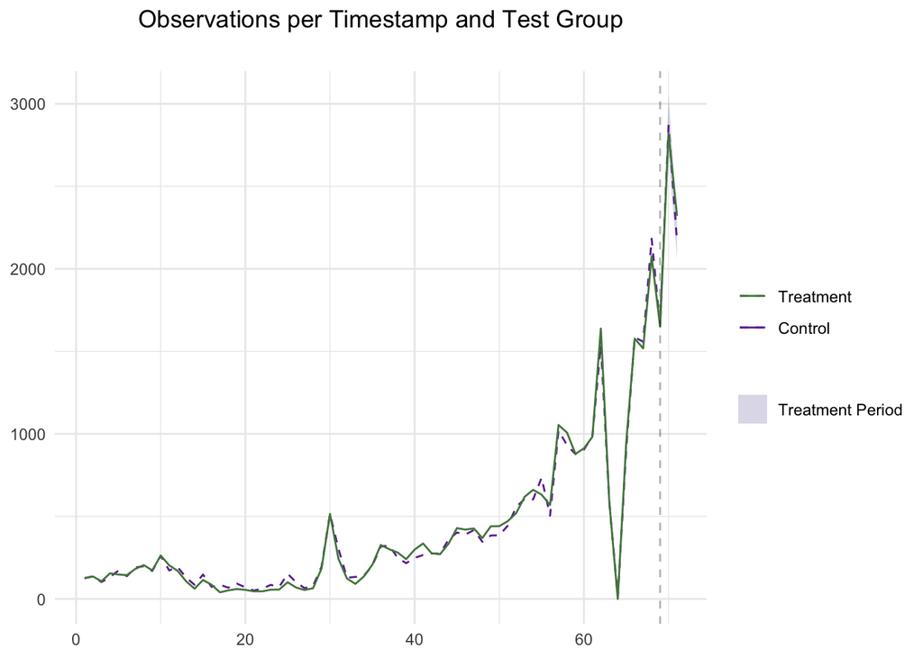

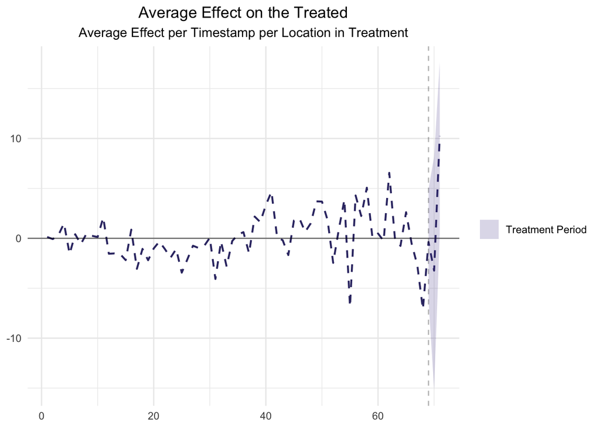

**Final Results after Model Augmentation**

| GeoLift Results Summary |
| --- |
| - Test Statistics |
| Average ATT: 2.204 |
| Percent Lift: 1.5% |
| Incremental Y: 99 |
| P-value: 0.07 |
| - Balance Statistics |
| L2 Imbalance: 20.023 |
| Scaled L2 Imbalance: 0.2044 |
| Percent improvement from naive model: 79.56% |
| Average Estimated Bias: 0.762 |

# Power Analysis Definitions

### Understanding Power Function Parameters

The key parameters needed to run this function in `4. Test Market Selection` are:

- **`data`**: A data frame containing the historical conversions by geographic unit. This object must contain at least a `"location"` column with the geo-name, a `"Y"` column with the outcome data (such as units), a `"time"` column with the indicator of the time period (starting at 1), and `covariates` (if available).
- **`treatment_periods`**: List of treatment periods to calculate power for. The ideal test length heavily depends on the product and vertical we are working with. Nevertheless, a good rule of thumb when deciding duration is to make sure that the test period can contain **at least** one full purchase cycle.
- **`N`**: List of number of test markets to calculate power for. The values in this list represent the different test-market sizes we want to explore. This parameter is often guided by the budget and scope of the test we want to implement. For our example, we could analyze smaller tests with two, three, and four test markets (the remaining would be part of the control) by setting this parameter to `N = c(2,3,4)`.
- **`X`** (Optional): List of the names of the `covariates` in the data.
- **`Y_id`, `location_id`,** and **`time_id`**: Names of the outcome, location, and time variables. These parameters will let our function know are the names of these variables in our data frame. If left empty, this parameter will default to the defaults of which are: `Y`, `location`, and `time`.
- **`effect_size`**: This parameter contains a vector of different effect sizes (or lifts) we want to simulate. Since these are relative values, they do depend on the product and vertical we’re analyzing. For instance, while a small single-digit percent increase in volume for a retailer can translate to millions of units, a large lift might be required for an automotive company that sells fewer products per day. By default this parameter is set to a sequence of lifts between 0 and 25 percent with 5% increments, that is, `seq(0,0.25,0.05)`.
- **`lookback_window`**: A number indicating how far back in time the simulations for the power analysis should go. For instance, a value equal to 5 would simulate power for the last five possible tests. In general, when the historical data is stable (it doesn’t vary wildly from one day/region to another) we can obtain a very robust and reliable power analysis by just looking into the most recent possible test (in other words, `lookback_window = 1`). It is important to mention that increasing the values in this parameter can significantly increase the algorithm’s run-time.
- **`include_markets`**: A list of markets or locations that should be part of the test group. Make sure the spelling of locations in this lists matches with the data.
- **`exclude_markets`**: A list of markets or locations that won’t be considered for the test market selection, but will remain in the pool of controls. As with `include_locations`, always make sure the spelling of locations in this lists matches with the data.
- **`holdout`**: A vector with two values: the first one the smallest desirable percentage of holdout. The holdout represents the share of conversions from markets that will not see our ad campaign. For example, we could specify that we’re fine with a minimum of 50% holdout and will therefore set `holdout = c(0.5, 1)`. If this parameter is left empty, all market selections will be analyzed regardless of their size.
- **`cpic`**: Value indicating the Cost Per Incremental Conversion, that is, on average how much do we typically need to spend to bring one incremental conversion. CPIC estimates can typically be obtained from Marketing Mix Models, Conversion Lifts, and previous experiments/geo-experiments. This value is key to get a good estimate of the budget that we will need to run a well-powered test. If there is no reliable information about the Cost Per Incremental Conversion, the default will be set to `cpic = 1`, in which case, the investment results will output the incremental units needed for a successful test. *If sales is used as the `'Y' metric, we will use ROAS instead.`*
- **`budget`**: Optional parameter that indicates the maximum budget available for a GeoLift test. If no budget is provided, all market selections will be analyzed by the algorithm.
- **`alpha`**: This parameter controls the significance Level that will be used by our model. By default `alpha = 0.1` which is equivalent to a 90% confidence level.
- **`model`**: A string that indicates the outcome model used to augment the Augmented Synthetic Control Method. Augmentation through a prognostic function can improve fit and reduce L2 imbalance metrics. The most common values used are: `model = "None"` (default) which won’t augment the ASCM and `model = "Ridge"`.
- [**`fixed_effects`**](https://www.kellogg.northwestern.edu/faculty/dranove/htm/dranove/coursepages/Mgmt%20469/Fixed%20Effects%20Models.pdf): A logic flag indicating whether to include unit Fixed Effects (FE) in the model. Fixed effects are an additional parameter that we can include into our models which represents a non-random component in our data. More specifically, in our model the FE represents the “level” of each region’s time-series across the data. By adding the FE we effectively remove this level - this allows our model to focus on explaining the variations from that level rather than the full value of `Y`. This is helpful when the series are stable across time. However, if the series isn’t stable (it has large spikes/valleys, has a clear trend, etc.), then it can actually be a detriment to our model. By default, this parameter is set to `fixed_effects = TRUE`. A close inspection of the date plot output combined with knowledge of the data is key to specify this parameter. We can set `fixed_effects = TRUE` *given we can observe a stable behavior of sales across our markets in the historical data.*
- **`Correlations`**: Given that not all locations in the pool of controls will contribute meaningfully to create our counterfactual/synthetic test region, the correlations can be a great resource to know how representative our test region is which can inform other analyses such as Marketing Mix Model calibration. By default this parameter is set to `Correlations = FALSE`.
- [**`side_of_test`**](https://stats.oarc.ucla.edu/other/mult-pkg/faq/general/faq-what-are-the-differences-between-one-tailed-and-two-tailed-tests/): A string indicating whether confidence will be determined using a one sided or a two sided test. These are the following valid values for this parameter:
  - **`side_of_test = "two_sided"`**: The test statistic is the sum of all treatment effects, i.e. sum(abs(x)). Defualt.
  - **`side_of_test = "one_sided"`**: One-sided test against positive or negative effects i.e. If the effect being applied is negative, then defaults to -sum(x). If the effect being applied is positive, then defaults to sum(x).

# Market Selections Output

### Understanding the Ranking Variables

The results of the power analysis and market selection from `4. Test Market Selection` provide several key metrics that we can use to select our test market. These metrics are:

- **ID**: Numeric ID that identifies a combination of test markets for a given duration. This variable will be useful to plot the results.
- **location**: Identifies the test locations.
- **duration**: Shows how many time-stamps the test will last for.
- **EffectSize**: The Effect Size represents minimum Lift needed to have a well-powered test. These values depend on the `effect_size` parameter of this function. Therefore, if you see multiple ties across top candidates for our test markets, then it might be a good idea to increase the granularity in this parameter (for example to `seq(0, 0.25, 0.01)`).
- **Power**: The row’s average power across all simulations at the specified `Effect Size`.
- [**AvgScaledL2Imbalance**](https://eml.berkeley.edu/~jrothst/workingpapers/ASCM_feb2021.pdf): The Scaled L2 Imbalance metric is a goodness of fit metric between 0 and 1 that represents how well the model is predicting the pre-treatment observed values through the Synthetic Control. Scaled L2 Imbalance values of 0 show a perfect match of pre-treatment values. Scaled L2 Imbalance values of 1 show that the Synthetic Control algorithm is not adding much value beyond what you could accomplish with a simple average of control locations (naive model).
- **Investment**: The average investment needed to obtain a well-powered test given a CPIC.
- **AvgATT**: The ATT (Average Estimated Treatment Effect) is a metric of how many incremental units, on average, our test markets will have across each time-stamp (daily, weekly) for the duration of the test for a given set of test markets, duration, and Effect Size.
- **Average_MDE**: The average Minimum Detectable Effect across all simulations.
- **ProportionTotal_Y**: This proportion reflects the fraction of all conversions that happen in our test regions compared to the aggregation of all markets. For example, a value of 0.10 would indicate that our test markets represent 10% of all conversions for our KPI.
- **abs_lift_in_zero**: This value represents the average estimated lift our test markets had when we actually simulated a 0% Lift in conversions. Great test market selections often have values of abs_lift_in_zero very close to zero.
- **Holdout**: The percent of total conversions in the control markets. This value is complementary to **ProportionTotal_Y**.
- **rank**: Ranking variable that summarizes the EffectSize, Power, AvgScaledL2Imbalance, Average_MDE, and abs_lift_in_zero to help you select the best combination of test markets. The ranking variable allows for ties.